# Customer Churn Analysis Project

**Author:** Harsh Meena

**Tools Used:** Python | Pandas | NumPy | Matplotlib | Seaborn | SciPy | Jupyter Notebook

## Problem Statement

-- Customer churn is a major challenge in the telecom industry.

-- High churn reduces revenue and increases customer acquisition costs.

**Goal:** Analyze the Kaggle Telco Customer Churn dataset to identify key drivers of churn and propose actionable business insights.

## Import Python libraries Used for this project

```python
import pandas as pd
import numpy as np
import matplotlib.pyplot as plt
import seaborn as sns
from scipy import stats
```

# Load dataset and Check First 5 Rows

```python
df = pd.read_csv("C:/Users/meena/Downloads/WA_Fn-UseC_-Telco-Customer-Churn.csv")

df.head()
```

|  | customerID | gender | SeniorCitizen | Partner | Dependents | tenure | PhoneService | MultipleLines | InternetService | OnlineSecurity | ... | DeviceProtection | TechSupport | StreamingTV | StreamingMovies | Contract | PaperlessBilling | PaymentMethod | MonthlyCharges | TotalCharges | Churn |
| --- | --- | --- | --- | --- | --- | --- | --- | --- | --- | --- | --- | --- | --- | --- | --- | --- | --- | --- | --- | --- | --- |
| 0 | 7590-VHVEG | Female | 0 | Yes | No | 1 | No | No phone service | DSL | No | ... | No | No | No | No | Month-to-month | Yes | Electronic check | 29.85 | 29.85 | No |
| 1 | 5575-GNVDE | Male | 0 | No | No | 34 | Yes | No | DSL | Yes | ... | Yes | No | No | No | One year | No | Mailed check | 56.95 | 1889.5 | No |
| 2 | 3668-QPYBK | Male | 0 | No | No | 2 | Yes | No | DSL | Yes | ... | No | No | No | No | Month-to-month | Yes | Mailed check | 53.85 | 108.15 | Yes |
| 3 | 7795-CFOCW | Male | 0 | No | No | 45 | No | No phone service | DSL | Yes | ... | Yes | Yes | No | No | One year | No | Bank transfer (automatic) | 42.30 | 1840.75 | No |
| 4 | 9237-HQITU | Female | 0 | No | No | 2 | Yes | No | Fiber optic | No | ... | No | No | No | No | Month-to-month | Yes | Electronic check | 70.70 | 151.65 | Yes |

5 rows × 21 columns

# Dataset Overview

-- Understand the structure, data types, and basic statistics of the dataset.

```python
df.info()
df.describe()
```

```
<class 'pandas.core.frame.DataFrame'>
RangeIndex: 7043 entries, 0 to 7042
Data columns (total 21 columns):
 #   Column            Non-Null Count  Dtype
---  ------            --------------  -----
 0   customerID        7043 non-null   object
 1   gender            7043 non-null   object
 2   SeniorCitizen     7043 non-null   int64
 3   Partner           7043 non-null   object
 4   Dependents        7043 non-null   object
 5   tenure            7043 non-null   int64
 6   PhoneService      7043 non-null   object
 7   MultipleLines     7043 non-null   object
 8   InternetService   7043 non-null   object
 9   OnlineSecurity    7043 non-null   object
 10  OnlineBackup      7043 non-null   object
 11  DeviceProtection  7043 non-null   object
 12  TechSupport       7043 non-null   object
 13  StreamingTV       7043 non-null   object
 14  StreamingMovies   7043 non-null   object
 15  Contract          7043 non-null   object
 16  PaperlessBilling  7043 non-null   object
 17  PaymentMethod     7043 non-null   object
 18  MonthlyCharges    7043 non-null   float64
 19  TotalCharges      7043 non-null   object
 20  Churn             7043 non-null   object
dtypes: float64(1), int64(2), object(18)
memory usage: 1.1+ MB
```

|  | SeniorCitizen | tenure | MonthlyCharges |
| --- | --- | --- | --- |
| count | 7043.000000 | 7043.000000 | 7043.000000 |
| mean | 0.162147 | 32.371149 | 64.761692 |
| std | 0.368612 | 24.559481 | 30.090047 |
| min | 0.000000 | 0.000000 | 18.250000 |
| 25% | 0.000000 | 9.000000 | 35.500000 |
| 50% | 0.000000 | 29.000000 | 70.350000 |
| 75% | 0.000000 | 55.000000 | 89.850000 |
| max | 1.000000 | 72.000000 | 118.750000 |

### Why

```python
df['TotalCharges'] = pd.to_numeric(df['TotalCharges'], errors='coerce')
df.dropna()
```

|  | customerID | gender | SeniorCitizen | Partner | Dependents | tenure | PhoneService | MultipleLines | InternetService | OnlineSecurity | ... | DeviceProtection | TechSupport | StreamingTV | StreamingMovies | Contract | PaperlessBilling | PaymentMethod | MonthlyCharges | TotalCharges | Churn |
| --- | --- | --- | --- | --- | --- | --- | --- | --- | --- | --- | --- | --- | --- | --- | --- | --- | --- | --- | --- | --- | --- |
| 0 | 7590-VHVEG | Female | 0 | Yes | No | 1 | No | No phone service | DSL | No | ... | No | No | No | No | Month-to-month | Yes | Electronic check | 29.85 | 29.85 | No |
| 1 | 5575-GNVDE | Male | 0 | No | No | 34 | Yes | No | DSL | Yes | ... | Yes | No | No | No | One year | No | Mailed check | 56.95 | 1889.50 | No |
| 2 | 3668-QPYBK | Male | 0 | No | No | 2 | Yes | No | DSL | Yes | ... | No | No | No | No | Month-to-month | Yes | Mailed check | 53.85 | 108.15 | Yes |
| 3 | 7795-CFOCW | Male | 0 | No | No | 45 | No | No phone service | DSL | Yes | ... | Yes | Yes | No | No | One year | No | Bank transfer (automatic) | 42.30 | 1840.75 | No |
| 4 | 9237-HQITU | Female | 0 | No | No | 2 | Yes | No | Fiber optic | No | ... | No | No | No | No | Month-to-month | Yes | Electronic check | 70.70 | 151.65 | Yes |
| ... | ... | ... | ... | ... | ... | ... | ... | ... | ... | ... | ... | ... | ... | ... | ... | ... | ... | ... | ... | ... | ... |
| 7038 | 6840-RESVB | Male | 0 | Yes | Yes | 24 | Yes | Yes | DSL | Yes | ... | Yes | Yes | Yes | Yes | One year | Yes | Mailed check | 84.80 | 1990.50 | No |
| 7039 | 2234-XADUH | Female | 0 | Yes | Yes | 72 | Yes | Yes | Fiber optic | No | ... | Yes | No | Yes | Yes | One year | Yes | Credit card (automatic) | 103.20 | 7362.90 | No |
| 7040 | 4801-JZAZL | Female | 0 | Yes | Yes | 11 | No | No phone service | DSL | Yes | ... | No | No | No | No | Month-to-month | Yes | Electronic check | 29.60 | 346.45 | No |
| 7041 | 8361-LTMKD | Male | 1 | Yes | No | 4 | Yes | Yes | Fiber optic | No | ... | No | No | No | No | Month-to-month | Yes | Mailed check | 74.40 | 306.60 | Yes |
| 7042 | 3186-AJIEK | Male | 0 | No | No | 66 | Yes | No | Fiber optic | Yes | ... | Yes | Yes | Yes | Yes | Two year | Yes | Bank transfer (automatic) | 105.65 | 6844.50 | No |

7032 rows × 21 columns

## Keep Relevant Columns

### Why

-- To focus only on the important features for churn analysis.  
-- This reduces noise in the dataset and makes analysis more efficient and business‑focused.

```python
df = df[['tenure', 'MonthlyCharges', 'TotalCharges', 'Contract', 'InternetService','PaymentMethod','Churn']]
df
```

|  | tenure | MonthlyCharges | TotalCharges | Contract | InternetService | PaymentMethod | Churn |
| --- | --- | --- | --- | --- | --- | --- | --- |
| 0 | 1 | 29.85 | 29.85 | Month-to-month | DSL | Electronic check | No |
| 1 | 34 | 56.95 | 1889.50 | One year | DSL | Mailed check | No |
| 2 | 2 | 53.85 | 108.15 | Month-to-month | DSL | Mailed check | Yes |
| 3 | 45 | 42.30 | 1840.75 | One year | DSL | Bank transfer (automatic) | No |
| 4 | 2 | 70.70 | 151.65 | Month-to-month | Fiber optic | Electronic check | Yes |
| ... | ... | ... | ... | ... | ... | ... | ... |
| 7038 | 24 | 84.80 | 1990.50 | One year | DSL | Mailed check | No |
| 7039 | 72 | 103.20 | 7362.90 | One year | Fiber optic | Credit card (automatic) | No |
| 7040 | 11 | 29.60 | 346.45 | Month-to-month | DSL | Electronic check | No |
| 7041 | 4 | 74.40 | 306.60 | Month-to-month | Fiber optic | Mailed check | Yes |
| 7042 | 66 | 105.65 | 6844.50 | Two year | Fiber optic | Bank transfer (automatic) | No |

7043 rows × 7 columns

## Churn Rate Calculation

### Why

-- To understand the overall business risk, we calculate the total number of customers and the percentage of those who churned.

```python
total_customers = df.shape[0]
churn_rate = df['Churn'].value_counts(normalize=True) ['Yes'] * 100

print("Total Customers:", total_customers)
print("Churn Rate 9%):", round(churn_rate,2))
```

```
Total Customers: 7043
Churn Rate 9%): 26.54
```

## Exploratory Data Analysis & Visualizations

## Churn Distribution

### Why

-- To visualize how many customers churned versus retained.  
-- This gives a quick overview of the churn problem and highlights the scale of business risk.

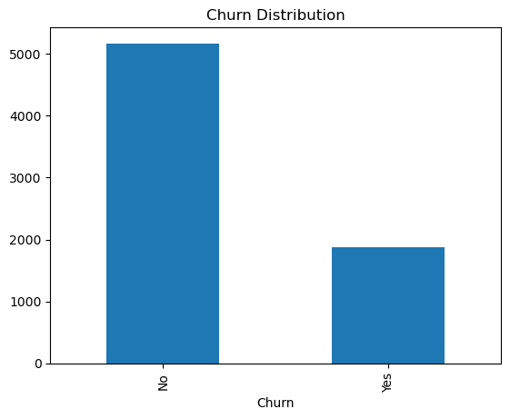

```python
df['Churn'].value_counts().plot(kind='bar', title='Churn Distribution')
plt.show()
```

## Tenure Distribution by Churn

### Why

-- Compare tenure of churned vs retained customers.

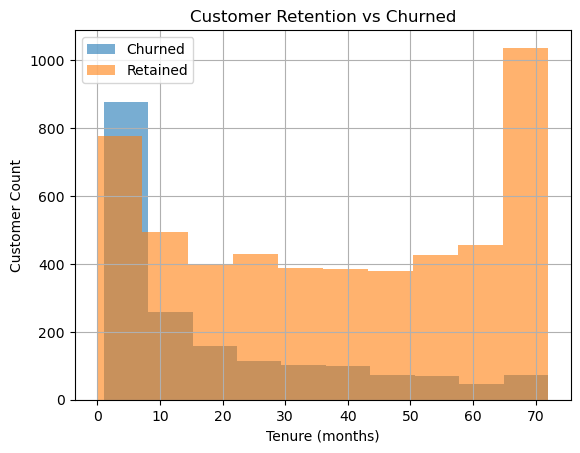

```python
df[df['Churn']=="Yes"]['tenure'].hist(alpha=0.6, label='Churned')
df[df['Churn']=="No"]['tenure'].hist(alpha=0.6, label='Retained')
plt.legend()
plt.title('Customer Retention vs Churned')
plt.xlabel('Tenure (months)')
plt.ylabel('Customer Count')
plt.show()
```

## Tenure vs Churn (Boxplot)

### Why

-- Compare tenure distribution between churned and retained customers.

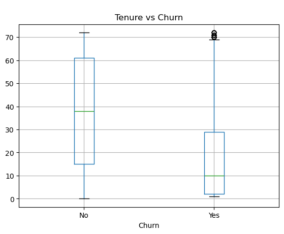

```python
df.boxplot(column='tenure', by='Churn')
plt.title('Tenure vs Churn')
plt.suptitle(' ')
plt.show()
```

## Contract Type vs Churn

### Why

-- To analyze how churn varies across different contract types.  
-- This helps identify whether short-term contracts are more prone to churn compared to long-term ones.

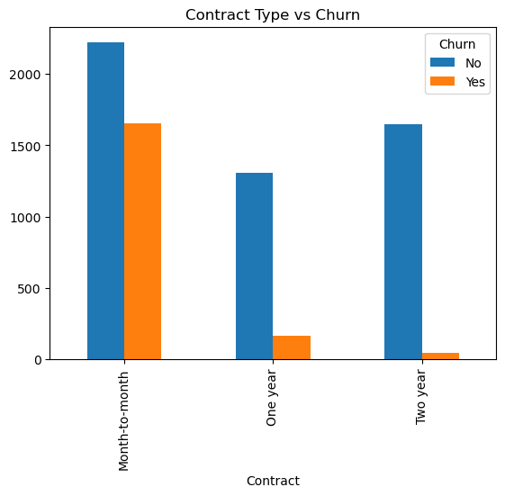

```python
pd.crosstab(df['Contract'], df['Churn']).plot(kind='bar')
plt.title('Contract Type vs Churn')
plt.show()
```

## Churn Rate by Internet Service

### Why

-- To analyze how churn rate differs across internet service types.  
-- This helps identify whether certain services are more prone to churn, guiding product and support improvements.

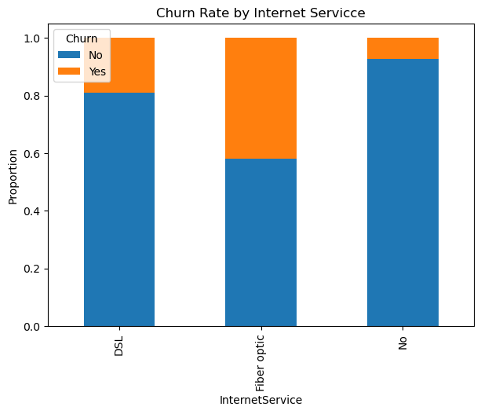

```python
pd.crosstab(df['InternetService'], df['Churn'], normalize='index').plot(kind='bar', stacked=True, figsize=(7,5))
plt.title('Churn Rate by Internet Servicce')
plt.ylabel('Proportion')
plt.show()
```

## Monthly Charges vs Churn

### Why

-- To check if churned customers pay different monthly charges compared to retained ones.  
-- This helps identify whether higher charges are linked to higher churn risk.

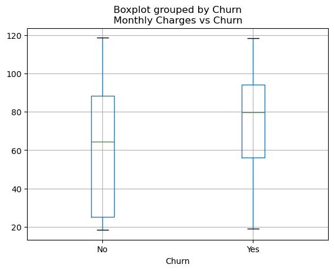

```python
df.boxplot(column='MonthlyCharges', by ='Churn')
plt.title('Monthly Charges vs Churn')
plt.show()
```

## Payment Method vs Churn

### Why

-- To analyze how churn differs across different payment methods.  
-- This helps identify whether certain payment methods are linked to higher churn risk.

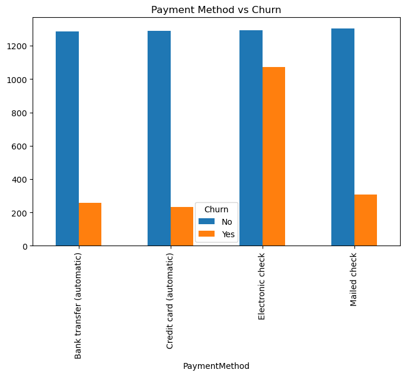

```python
pd.crosstab(df['PaymentMethod'], df['Churn']).plot(kind='bar', figsize=(8,5))
plt.title('Payment Method vs Churn')
plt.show()
```

## Churn Rate by Contract Type

### Why

-- To understand how churn rate changes with different contract types.  
-- This helps identify whether long-term contracts reduce churn compared to short-term ones.

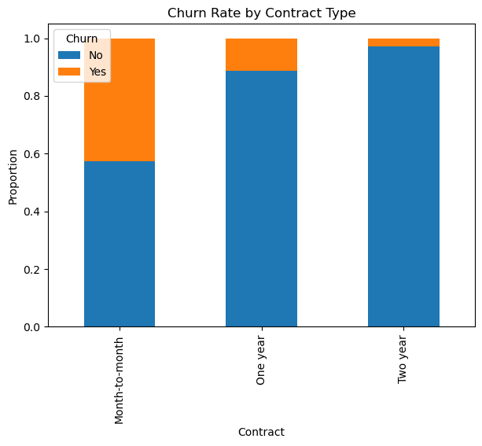

```python
pd.crosstab(df['Contract'], df['Churn'], normalize='index').plot(kind='bar', stacked=True, figsize=(7,5))
plt.title('Churn Rate by Contract Type')
plt.ylabel('Proportion')
plt.show()
```

## Correlation Matrix

### Why

-- To examine relationships between tenure, monthly charges, and churn.  
-- Correlation helps identify whether higher charges or shorter tenure are linked to churn risk.

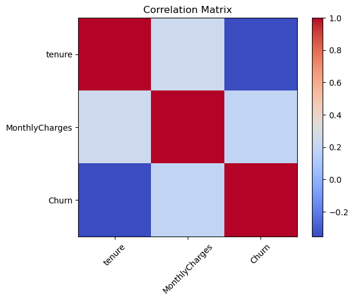

```python
df_corr = df.copy()
df_corr['Churn'] = df_corr['Churn'].map({'Yes':1, 'No':0})

corr = df_corr[['tenure', 'MonthlyCharges', 'Churn']].corr()

plt.imshow(corr, cmap='coolwarm')
plt.colorbar()
plt.xticks(range(len(corr.columns)), corr.columns, rotation=45)
plt.yticks(range(len(corr.columns)), corr.columns)
plt.title('Correlation Matrix')
plt.show()
```

## Hypothesis Testing: Tenure vs Churn

### Why

-- To test whether the average tenure of churned customers is significantly different from that of retained customers.  
-- This helps confirm if shorter tenure is statistically linked to higher churn.

```python
churned = df[df['Churn']=="Yes"]['tenure']
retained = df[df['Churn']=="No"]['tenure']

t_stat, p_value = stats.ttest_ind(churned, retained)
print("T-statistics:", t_stat)
print("P-value:", p_value)
```

```
T-statistics: -31.57955051135377
P-value: 7.99905796059022e-205
```

## Tenure vs Churn (Boxplot with P-value)

### Why

-- To visualize tenure differences between churned and retained customers, and show statistical significance using the p-value.  
-- This confirms whether shorter tenure is strongly associated with churn.

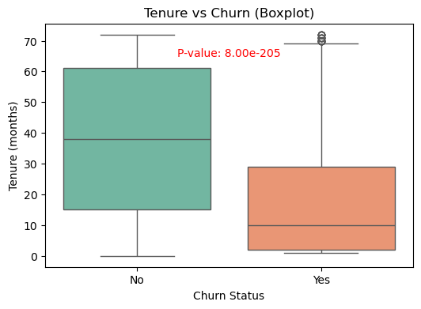

```python
plt.figure(figsize=(6,4))
sns.boxplot(x='Churn', y='tenure', data=df,hue='Churn', palette='Set2', legend=False)

plt.title('Tenure vs Churn (Boxplot)')
plt.xlabel('Churn Status')
plt.ylabel('Tenure (months)')

# annotate p-value
plt.text(0.5, df['tenure'].max()*0.9, f"P-value: {p_value:.2e}",
         ha='center', fontsize=10, color='red')

plt.show()
```

## Hypothesis Testing: Tenure vs Churn

### Hypotheses

- **H₀ (Null Hypothesis):** Average tenure of churned and retained customers is the same.
- **H₁ (Alternative Hypothesis):** Average tenure of churned customers is different (shorter) than retained customers.

### Test Result

- **T-statistic:** Negative value → churned customers have lower tenure.
- **P-value:** Very small (≈ 0.00).

### Conclusion

Reject **H₀**.  
There is a statistically significant difference: churned customers have **shorter tenure** compared to retained ones.

## Summary

This project combines EDA, visualization, and hypothesis testing to provide actionable insights. It demonstrates Python analytics skills, statistical reasoning, and business acumen.

```python
import os

# Check if 'data' folder exists, if not create it
if not os.path.exists('data'):
    os.makedirs('data')

# Now save the cleaned dataset
df.to_csv("data/cleaned_churn.csv", index=False)
print("Cleaned dataset saved successfully!")
```

```
Cleaned dataset saved successfully!
```